# Literary Concerns and Word Order Dependent Methods

PS239T

Fall 2015

**CREDITS**: These materials were written by Teddy Roland.

### Setup Environment

```r
rm(list=ls())
setwd("~/Dropbox/berkeley/Dissertation/Data\ and\ Analyais/Git\ Repos/text-analysis-dhbsi")

library(tm)
library(RTextTools) # a machine learning package for text classification written in R
library(qdap) # quantiative discourse analysis
library(entropy) # tools applying Information Theory
```

# 1. Alliteration: Counting

Unlike many computational studies on novels, when we look at poetry – and especially poetic form – we are often interested not in the words themselves but their sounds. Essentially, this is the difference between orthography and phonology. Although there are many languages in which there is a one-to-one mapping between letters and sounds, this is not the case for English. Fortunately, there are several publicly available pronouncing dictionaries, such as the CMU Pronouncing Dictionary and Nettalk. These dictionaries include information about syllable units, stress, and phonemes – and in some cases multiple pronunciations.

Of course, when we study poetic form we are interested not only in sounds but their sequences and repetitions, which means that a bag-of-words model might only have limited application. In practice, the methods used to study poetic form typically begin with dictionary lookup methods (not unlike we did with sentiment analysis) and incorporate some kind of pattern recognition, increasingly using statistics. This lesson will walk through some of those lookups and start to think about strategies for finding patterns.

```r
# Load Data
sonnets.df <- read.csv('Data/shakes-sonnets.tsv', header=FALSE, sep="\t", as.is=TRUE)

# Take a peek: Each row contains one sonnet and each column contains one line
head(truncdf(sonnets.df),10)
```

```
##            V1         V2         V3         V4         V5         V6         V7         V8         V9        V10        V11        V12        V13        V14 V15
## 1  FROM faire That there But as the His tender But thou,  Feed'st th Making a f Thyself th Thou that  And only h Within thi And, tende Pity the w To eat the
## 2  When forty And dig de Thy youth' Will be a  Then being Where all  To say, wi Were an al How much m If thou co Shall sum  Proving hi This were  And see th
## 3  Look in th Now is the Whose fres Thou dost  For where  Disdains t Or who is  Of his sel Thou art t Calls back So thou th Despite of But if tho Die single
## 4  Unthrifty  Upon thyse Nature's b And being  Then, beau The bounte Profitless So great a For having Thou of th Then how,  What accep Thy unused Which, use
## 5  Those hour The lovely Will play  And that u For never- To hideous Sap check' Beauty o'e Then, were A liquid p Beauty's e Nor it nor But flower Leese but
## 6  Then let n In thee th Make sweet With beaut That use i Which happ That's for Or ten tim Ten times  If ten of  Then what  Leaving th Be not sel To be deat
## 7  Lo! in the Lifts up h Doth homag Serving wi And having Resembling Yet mortal Attending  But when f Like feebl The eyes,  From his l So thou, t Unlook'd o
## 8  Music to h Sweets wit Why lovest Or else re If the tru By unions  They do bu In singlen Mark how o Strikes ea Resembling Who all in Whose spee Sings this
## 9  Is it for  That thou  Ah! if tho The world  The world  That thou  When every By childre Look, what Shifts but But beauty And kept u No love to That on hi
## 10 For shame! Who for th Grant, if  But that t For thou a That 'gain Seeking th Which to r O, change  Shall hate Be, as thy Or to thys Make thee  That beaut
```

“unlist” is a function to take entries from a two-dimensional structures like a data frame and turn them into a one-dimensional list. This will come in handy when we want to perform an operation on every entry.

```r
# Get a list of all lines in the sonnets
all_lines = unlist(sonnets.df)
```

“syllable_sum” in the qdap package is a powerful function for syllable counting. It first checks the Nettalk pronouncing dictionary to check whether it knows the number of syllables already, and failing that, uses machine learning to guess the number of syllables based on orthography.

```r
# Count the number of syllables per line in all sonnets
all_sylls = syllable_sum(all_lines)

# Check results
all_sylls
```

```
##    [1] 10 10 11 11  9 10 11 11 10 11 11 10 10 10 10 10 10 10 10 11 10 10 10
##   [24] 10 10 10 10 10 10 10  9 10 12 11 10 10 10 10 10 10 10 10 10 10 10 10
##   [47] 10 11 10 10 10 10 10 11 10 10 10 10 10 10 11 10 10 10 10 10 10 10 10
##   [70] 10 10 10 10 10 10 10 10 10 10 10 10 10 10 10 11 10 11 10 10 10 10 10
##   [93] 10 11 10 10 10 10 10 10 10 11 10 10 10 10 10 10 10 10 10 11 10 11 10
##  [116] 10 10 10 10 10 10 10 10 10 10 11 10 10 12 10 10 10 10 10 10 10 10 10
##  [139] 10 10 10 10 11 10  8 10 10 10 10 12 10 10 10 11 10 10 11 10 10 10 10
##  [162] 10 11 10 11 11 10 10 11 10 10 10 10 11 10 10 11 10 10 10 10 10 10 10
##  [185]  9 11 11 10  9 10 10 10 10 10 10 11 11 11 10 10 11  9 10 10 10 10 10
##  [208] 10 10 10 10 11 10 10 10 10 11 10 11 10 10 11 10 10 10 10 10 10 11 10
##  [231] 10 10 10 11 11 10 10 10 10 10 10 10 10 10 10  9  9 10 10 10 10 10 10
##  [254] 10 10 10 10 10  9 10 10 11 10 10 10 10 10 10 12 10 10 10 10 10 11 10
##  [277] 10 11 10 10 10 10 10 10 11 10 10 10 10 10 10 10 10 11 10 11 10 10  8
##  [300]  9 10 10 10 10 10 11  9 10 10 10 11 10 10 10 10 13 10 11 11 10 10 10
##  [323] 10 10 11 10 10 11 11 10 10 10 10 10 10 10 11 11 10 10 10 10  9 10 10
```

[output cut: 86 more lines]

Shakespeare’s sonnets are a famous and extensive example of iambic pentameter, which is in part characterized by a ten syllable line. We can check the consistency of that syllable count, using a couple basic statistics.

Note that when we checked all_sylls, r had introduced an “NA” wherever it had expected to find a line of poetry but didn’t (since the number of lines varies across in the cycle). We will remove these before our statistical measures.

```r
# Median syllable count (Half of all counts above, half below)
median(all_sylls, na.rm=TRUE)
```

```
## [1] 10
```

```r
# Max/Min syllable counts
range(all_sylls, na.rm=TRUE)
```

```
## [1]  3 13
```

```r
# Inter-Quartile Range (Difference across the middle fifty-percent of all counts)
IQR(all_sylls, na.rm=TRUE)
```

```
## [1] 0
```

Let’s look more closely at just one sonnet to see what’s happening under the hood.

```r
# Get a vector of lines in the eighth sonnet
eighth_sonn <- unlist(sonnets.df[8,])
eighth_sonn
```

```
##                                                      V1
##          "Music to hear, why hear'st thou music sadly?"
##                                                      V2
##      "Sweets with sweets war not, joy delights in joy."
##                                                      V3
## "Why lovest thou that which thou receivest not gladly,"
##                                                      V4
##          "Or else receivest with pleasure thine annoy?"
##                                                      V5
##             "If the true concord of well-tuned sounds,"
##                                                      V6
##               "By unions married, do offend thine ear,"
##                                                      V7
##         "They do but sweetly chide thee, who confounds"
##                                                      V8
##      "In singleness the parts that thou shouldst bear."
##                                                      V9
##        "Mark how one string, sweet husband to another,"
##                                                     V10
##              "Strikes each in each by mutual ordering,"
##                                                     V11
##            "Resembling sire and child and happy mother"
##                                                     V12
##            "Who all in one, one pleasing note do sing:"
##                                                     V13
##       "Whose speechless song, being many, seeming one,"
##                                                     V14
##    "Sings this to thee: 'thou single wilt prove none.'"
##                                                     V15
##                                                      ""
```

```r
# Take a look at the syllable counts
eighth_syll <- syllable_sum(eighth_sonn)
eighth_syll
```

```
##  [1] 11 10 13 11  9 10 10 10 11 11 11 10 11 10 NA
```

```r
# Get those stats
median(eighth_syll, na.rm = T)
```

```
## [1] 10.5
```

```r
IQR(eighth_syll, na.rm = T)
```

```
## [1] 1
```

```r
get.iqr <- function(poem){
  sonn <- unlist(sonnets.df[poem,])
  syll <- syllable_sum(sonn)
  return(IQR(syll, na.rm = T))
}

seq <- 1:154
x <- sapply(seq, get.iqr)
which(x >= 1)
```

```
##  [1]   5   8   9  11  26  33  40  42  58  88  94 114 119 121 126 152
```

EXERCISE: Find another sonnet that has an IQR greater than 0.

“syllable_sum” relies on a broader function called “syllable_count” that gives some more information.

```r
# Check the first line
eighth_sonn[[1]]
```

```
## [1] "Music to hear, why hear'st thou music sadly?"
```

```r
# Get syllable information for just the first line.
syllable_count(eighth_sonn[[1]])
```

```
##    words syllables in.dictionary
## 1  music         2             -
## 2     to         1             -
## 3   hear         1             -
## 4    why         1             -
## 5 hearst         1            NF
## 6   thou         1             -
## 7  music         2             -
## 8  sadly         2            NF
```

Okay, now let’s break the function. “syllable_sum” is very good at counting syllables, but let’s say we wanted to study alliteration in the sonnets, which requires a little more information about pronunciations.

The documentation indicates that the function begins with a dictionary lookup from the “Nettalk Corpus”, that is publicly available on the internet.

```r
# Documentation for syllable_sum
help(syllable_sum)

# Load the Nettalk dictionary
nettalk.df <- read.csv('Data/nettalk.data.tsv', header=FALSE, sep="\t", as.is=TRUE)

# Take a look
head(nettalk.df)
```

```
##         V1       V2       V3 V4
## 1 aardvark a-rdvark 1<<<>2<<  0
## 2    aback    xb@k-    0>1<<  0
## 3   abacus   @bxkxs   1<0>0<  0
## 4    abaft    xb@ft    0>1<<  0
## 5  abalone  @bxloni  2<0>1>0  0
## 6  abandon  xb@ndxn  0>1<>0<  0
```

If we’re going to perform our own lookups in the dictionary, we have to do some legwork that “syllable_sum” had done under the hood.

```r
# Tokenize the first line of the eighth sonnet
tokens <- gsub("[[:punct:]]", " ", eighth_sonn[[1]])
tokens <- MC_tokenizer(tokens)
tokens <- tolower(tokens)

# Create a function to look up the entry for a given word word
dict.lookup <- function(x) nettalk.df[nettalk.df[1]==as.vector(x)][2]

# Do the look-ups over each token
pronunciations <- sapply(tokens, dict.lookup)

# Check the results
pronunciations
```

```
##   music      to    hear             why    hear      st    thou   music
## "mYzIk"    "to"  "hI-r"      NA   "why"  "hI-r"      NA  "D-W-" "mYzIk"
##   sadly
##      NA
```

Now that we have information about the pronunciation about *most* syllables, we can start to think about alliteration.

```r
# Create a function to get the first phoneme of each word
initial <- function(x) substr(x,1,1)

# Get the first phoneme from each word's pronunciation
first.phoneme <- sapply(pronunciations, initial)

# Count the frequency of each phoneme
table(first.phoneme)
```

```
## first.phoneme
## D h m t w
## 1 2 2 1 1
```

EXERCISE: Using the table returned above, make R count the following:

1. How many syllables contain alliteration?
2. How many different alliterating sounds are there?

(Hint: The table is a numeric vector.)

CHALLENGE: Rewrite the script so that it returns a vector containing the number of alliterating syllables in every line of the eighth sonnet.

# 2. Part-of-Speech Tagging

Part of Speech tagging is used for a great variety of tasks, including Named Entity Recognition (NER) which can help to identify characters in a text as well as higher order problems like determining who is the subject or object of an action. Another type of question we can ask is about the grammatical sophistication of a text. One version of this is treated as the text’s “reading level,” while in literature this may be thought of as the grammatical mode by which a text explores its content.

```r
# Load corpus of novels
documents<-Corpus(DirSource("Data/POS-fiction"))

# Take a peek at the novels
# The double brackets call up different novels: 1 = A Game of Thrones; 2 = Beloved
head(as.character(documents$content[[1]]))
```

```
## [1] "PROLOGUE"
## [2] "“We should start back,” Gared urged as the woods began to grow dark around them. “The wildlings are dead.”"
## [3] "“Do the dead frighten you?” Ser Waymar Royce asked with just the hint of a smile."
## [4] "Gared did not rise to the bait. He was an old man, past fifty, and he had seen the lordlings come"
## [5] "and go. “Dead is dead,” he said. “We have no business with the dead.”"
## [6] "“Are they dead?” Royce asked softly. “What proof have we?”"
```

Importing the novel had introduced section breaks across paragraphs that we don’t need, but on the other hand, we want to split the text into sentences.

```r
# Combine sections of text
one.string <- paste(documents$content[[1]], collapse = " ")

# Split into sentences
sentences <- sent_detect(one.string)
```

Now that the text is divided into more grammatically meaningful units, we can start looking at Parts of Speech.

```r
# Check out the POS Tags
pos_tags()
```

```
##    Tag  Description
## 1  CC   Coordinating conjunction
## 2  CD   Cardinal number
## 3  DT   Determiner
## 4  EX   Existential there
## 5  FW   Foreign word
## 6  IN   Preposition or subordinating conjunction
## 7  JJ   Adjective
## 8  JJR  Adjective, comparative
## 9  JJS  Adjective, superlative
## 10 LS   List item marker
## 11 MD   Modal
## 12 NN   Noun, singular or mass
## 13 NNS  Noun, plural
## 14 NNP  Proper noun, singular
```

[output cut: 22 more lines]

```r
# Run Part-of-Speech tagger over the novels
# posd <- pos(sentences)

# if pressed for time
posd <- pos(head(sentences))
# check it out
posd
```

```
##   wrd.cnt       CC      CD       DT       IN       JJ      MD       NN      NNS      PRP       RB       TO       VB      VBD      VBN      VBP
## 1      16        0       0  1(6.2%) 2(12.5%)        0 1(6.2%) 2(12.5%)  1(6.2%) 2(12.5%)  1(6.2%)  1(6.2%) 2(12.5%)  1(6.2%) 2(12.5%)        0
## 2       4        0       0 1(25.0%)        0 1(25.0%)       0        0 1(25.0%)        0        0        0        0        0        0 1(25.0%)
## 3       5        0       0 1(20.0%)        0        0       0 1(20.0%)        0 1(20.0%)        0        0 2(40.0%)        0        0        0
## 4      11        0       0 2(18.2%) 2(18.2%)        0       0 5(45.5%)        0        0  1(9.1%)        0        0  1(9.1%)        0        0
## 5       7        0       0 1(14.3%)        0        0       0 1(14.3%)        0        0 1(14.3%) 1(14.3%) 1(14.3%) 2(28.6%)        0        0
## 6      16 2(12.5%) 1(6.2%) 2(12.5%)  1(6.2%)  1(6.2%)       0  1(6.2%)  1(6.2%) 2(12.5%)        0        0        0 2(12.5%)  1(6.2%) 2(12.5%)
```

The “pos” function returns a great deal of information, including not only the text itself, but full sentences in which each word appears with its tag, and counts of the tags themselves. We’re especially interested in the kind of information reported in the value “POStagged”.

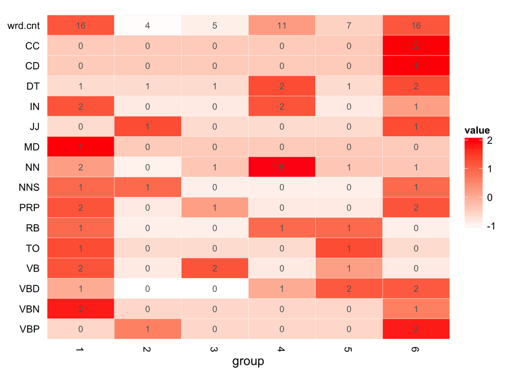

```r
# visualize parts of speech per sentence
plot(posd)
```

```r
# view sentences with tags in-line, list of tags by sentence, & word counts
posd$POStagged
```

```
##                                                                                                                                     POStagged
## 1 prologue/NN we/PRP should/MD start/VB back/RB gared/VBN urged/VBN as/IN the/DT woods/NNS began/VBD to/TO grow/VB dark/NN around/IN them/PRP
## 2                                                                                                        the/DT wildlings/NNS are/VBP dead/JJ
## 3                                                                                                    do/VB the/DT dead/NN frighten/VB you/PRP
## 4                                                      ser/NN waymar/NN royce/NN asked/VBD with/IN just/RB the/DT hint/NN of/IN a/DT smile/NN
## 5                                                                                       gared/VBD did/VBD not/RB rise/VB to/TO the/DT bait/NN
## 6              he/PRP was/VBD an/DT old/JJ man/NN past/IN fifty/CD and/CC he/PRP had/VBD seen/VBN the/DT lordlings/NNS come/VBP and/CC go/VBP
##                                                                  POStags
## 1   NN, PRP, MD, VB, RB, VBN, VBN, IN, DT, NNS, VBD, TO, VB, NN, IN, PRP
## 2                                                       DT, NNS, VBP, JJ
## 3                                                    VB, DT, NN, VB, PRP
## 4                            NN, NN, NN, VBD, IN, RB, DT, NN, IN, DT, NN
## 5                                           VBD, VBD, RB, VB, TO, DT, NN
## 6 PRP, VBD, DT, JJ, NN, IN, CD, CC, PRP, VBD, VBN, DT, NNS, VBP, CC, VBP
##   word.count
## 1         16
## 2          4
## 3          5
## 4         11
## 5          7
## 6         16
```

EXERCISE: Use R to retrive the vector of tagged sentences from ‘posd’

CHALLENGE: Count the number of instances of each POS tag.

The in-line tags might be useful if we wished to, say, idenitify the frequencies of nouns across our texts. For this particular project, we’ll use the list of tags to compute bigram frequencies.

```r
# Get list of tags for each sentence
posd.list <- posd[[2]][[2]]

# Shorten tags to two characters
posd.list<-lapply(posd.list, function(x) sapply(x, function(x) substr(x,1,2)))

# Get bigrams of POS tags
pos.grams <- lapply(posd.list, function(x) ngrams(paste(x, collapse = " "), 2))

# Get the list of bigrams for each sentence
gram.list <-sapply(pos.grams, function(x) x$all_n$n_2)

# Pull out all the bigrams into a single list, since we no longer are interested in sentence divisions
gram.list <- unlist(gram.list, recursive=FALSE)

# Join bigrams with a hyphen into a single unit
gram.list<-sapply(gram.list, function(x) paste(x, sep=' ',collapse = '-'))

# Count the instances of all bigram units
gram.counts <- as.vector(table(gram.list))

# Take a look
gram.counts
```

```
##  [1] 1 1 1 1 7 1 2 1 1 1 1 3 2 1 5 1 2 1 2 1 1 1 3 2 1 1 1 2 2 3
```

And now that we have counted the total instances of each bigram, we can calculate the degree of grammatical entropy – something like its complexity – using Shannon’s formula for informational entropy: -SUM(p(x)*log(p(x)))

```r
# Get the probability of randomly choosing a particular bigram from the text
prob<-gram.counts/sum(gram.counts)

# Caculate the Shannon entropy of the text
Shannon.entropy <- -sum(log2(prob)*prob)
Shannon.entropy
```

```
## [1] 4.604792
```

```r
# ...or we can just use the entropy function
entropy(gram.counts, unit='log2')
```

```
## [1] 4.604792
```

EXERCISE: Find the grammatical entropy of a pair of texts from your own corpus. How do they compare to one another?